# R Notebook

```r
set.seed(32)
#Load Libraries
library(rjags)
library(dplyr)
library(ggplot2)
library(corrplot)
library(tidyr)
```

```r
#Read csv
adm_data <- read.csv("admission_data.csv", header=T)
adm_data
```

| GRE.Score | TOEFL.Score | University.Rating | SOP | LOR | CGPA | Research | Chance.of.Admit |
| --- | --- | --- | --- | --- | --- | --- | --- |
| 337 | 118 | 4 | 4.5 | 4.5 | 9.65 | 1 | 0.92 |
| 324 | 107 | 4 | 4.0 | 4.5 | 8.87 | 1 | 0.76 |
| 316 | 104 | 3 | 3.0 | 3.5 | 8.00 | 1 | 0.72 |
| 322 | 110 | 3 | 3.5 | 2.5 | 8.67 | 1 | 0.80 |
| 314 | 103 | 2 | 2.0 | 3.0 | 8.21 | 0 | 0.65 |
| 330 | 115 | 5 | 4.5 | 3.0 | 9.34 | 1 | 0.90 |
| 321 | 109 | 3 | 3.0 | 4.0 | 8.20 | 1 | 0.75 |
| 308 | 101 | 2 | 3.0 | 4.0 | 7.90 | 0 | 0.68 |
| 302 | 102 | 1 | 2.0 | 1.5 | 8.00 | 0 | 0.50 |
| 323 | 108 | 3 | 3.5 | 3.0 | 8.60 | 0 | 0.45 |

[output cut: 490 more lines]

#Exploratory Data Analysis

## Data Understanding

```r
#Structure of the dataset
str(adm_data)
```

```
'data.frame':   500 obs. of  8 variables:
 $ GRE.Score        : int  337 324 316 322 314 330 321 308 302 323 ...
 $ TOEFL.Score      : int  118 107 104 110 103 115 109 101 102 108 ...
 $ University.Rating: int  4 4 3 3 2 5 3 2 1 3 ...
 $ SOP              : num  4.5 4 3 3.5 2 4.5 3 3 2 3.5 ...
 $ LOR              : num  4.5 4.5 3.5 2.5 3 3 4 4 1.5 3 ...
 $ CGPA             : num  9.65 8.87 8 8.67 8.21 9.34 8.2 7.9 8 8.6 ...
 $ Research         : int  1 1 1 1 0 1 1 0 0 0 ...
 $ Chance.of.Admit  : num  0.92 0.76 0.72 0.8 0.65 0.9 0.75 0.68 0.5 0.45 ...
```

```r
#Summary of the dataset
summary(adm_data)
```

```
   GRE.Score      TOEFL.Score    University.Rating      SOP             LOR
 Min.   :290.0   Min.   : 92.0   Min.   :1.000     Min.   :1.000   Min.   :1.000
 1st Qu.:308.0   1st Qu.:103.0   1st Qu.:2.000     1st Qu.:2.500   1st Qu.:3.000
 Median :317.0   Median :107.0   Median :3.000     Median :3.500   Median :3.500
 Mean   :316.5   Mean   :107.2   Mean   :3.114     Mean   :3.374   Mean   :3.484
 3rd Qu.:325.0   3rd Qu.:112.0   3rd Qu.:4.000     3rd Qu.:4.000   3rd Qu.:4.000
 Max.   :340.0   Max.   :120.0   Max.   :5.000     Max.   :5.000   Max.   :5.000
      CGPA          Research    Chance.of.Admit
 Min.   :6.800   Min.   :0.00   Min.   :0.3400
 1st Qu.:8.127   1st Qu.:0.00   1st Qu.:0.6300
 Median :8.560   Median :1.00   Median :0.7200
 Mean   :8.576   Mean   :0.56   Mean   :0.7217
 3rd Qu.:9.040   3rd Qu.:1.00   3rd Qu.:0.8200
 Max.   :9.920   Max.   :1.00   Max.   :0.9700
```

## Check for Unwanted Values

```r
#Check for duplicate data
sum(duplicated(adm_data))
```

```
[1] 0
```

No duplicates.

```r
#Check for NA values
colSums(is.na(adm_data))
```

```
        GRE.Score       TOEFL.Score University.Rating               SOP
                0                 0                 0                 0
              LOR              CGPA          Research   Chance.of.Admit
                0                 0                 0                 0
```

No NA values were found.

## Univariate Analysis

```r
#Transform the data
df_scaled <- as.data.frame(scale(adm_data))
```

We transform the data to improve readability.

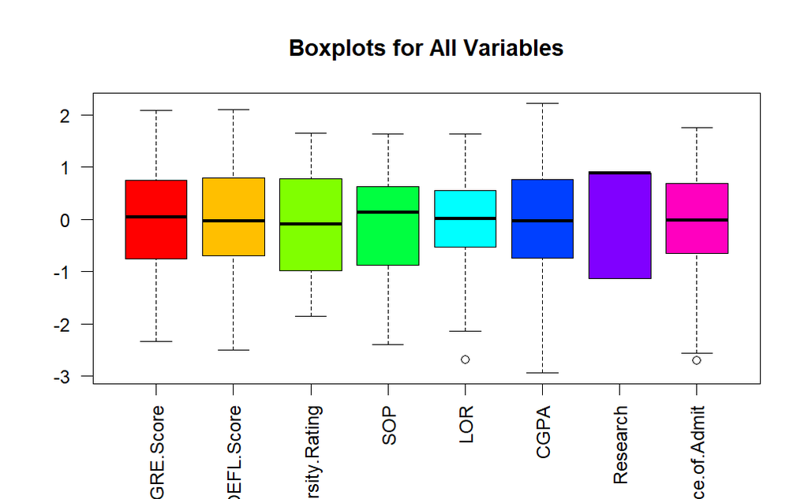

```r
boxplot(df_scaled,
        main = "Boxplots for All Variables",
        col = rainbow(ncol(adm_data)), # Different colors for each boxplot
        las = 2,                # Rotate x-axis labels
        outline = TRUE)
```

We can see from the analysis that there are only a few outliars, but not enough to do Robust Scaling.

# Multivariate Analysis

For the multivariate analysis, we will be using a correlation plot to determine the relationship between the weights to each other and the weights to the response variable (Chance of Admit)

```r
cor_data <- as.data.frame(as.table(cor(adm_data)))
cor_data$Freq = round(cor_data$Freq, 2)
```

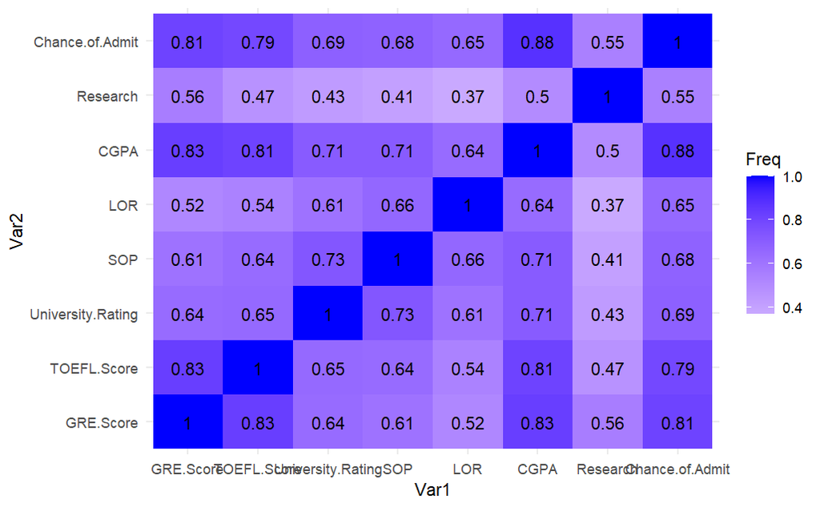

```r
ggplot(cor_data, aes(Var1, Var2, fill = Freq)) +
  geom_tile() +
  scale_fill_gradient2(low="red", mid = "white", high = "blue", midpoint=0) +
  geom_text(aes(label=Freq), color = "black")+
  theme_minimal()
```

```r
NA
NA
```

> From the correlation plot, we can deduce that all 7 covariates have significance towards the response variable (Chance.To.Admit).

# Data Preprocessing

```r
#Initialize Data
x <- subset(adm_data, select = -Chance.of.Admit)
y <- adm_data$Chance.of.Admit
n <- nrow(adm_data)
col <- ncol(x)
```

## Data Splitting

We split the data into train and test data to accurately predict the MSE (Mean Squared Error) and overall accuracy of the model.

```r
#Split size
idx_train <- sample(1:n, 0.8*n)

#Split the Data
x_train = x[idx_train, ]
x_test = x[-idx_train, ]
y_train = y[idx_train]
y_test = y[-idx_train]
```

## Scaling the Data

We scale the data to help the model better find convergence.

```r
#Scale the data to help with convergence
x_train_scaled <- scale(x_train)
x_test_scaled <- scale(x_test)
```

#Modelling

For the model, we will use JAGS implemented in R as the basis.

```r
model_str <- "
  model{
    for(i in 1:N){
      Y[i] ~ dbeta(phi*mu[i], phi * (1-mu[i]))
      logit(mu[i]) <- beta_0 + inprod(beta[1:col], x[i, 1:col])
      log_lik[i] <- logdensity.beta(Y[i], mu[i] * phi, (1 - mu[i]) * phi)
    }

    #Priors
    beta_0 ~ dnorm(0, 1)

    for(i in 1:col){
      beta[i] ~ dnorm(0, 1)
    }
    phi ~ dgamma(0.001, 0.001)
  }
"
```

```r
#Initialize the data list
data_list <- list(
  x = x_train_scaled,
  Y = y_train,
  N = length(idx_train),
  col = col
)
```

```r
#Initial Values For Each Variable
inits <- function() {
  beta_inits <- rnorm(ncol(x), 0, 1)
  phi_init <- rgamma(1,2,1)
  list(
    beta_0 = rnorm(1, 0, 1),
    beta = beta_inits,
    phi = max(phi_init, 0.01)
  )
}
```

```r
#Create the Model
model_beta <- jags.model(
  textConnection(model_str),
  data = data_list,
  inits = inits,
  n.chains = 5
)
```

[output not shown]

## Burn-in Process

The burn-in process is done to prevent the model to falsely diagnose the first few iterations (the learning process of the model) as divergency.

```r
update(model_beta, 1e3) #1000 iterations
```

[output not shown]

## Sampling

Sampling is done to take examples from the model to be able to interpret it.

```r
samples <- coda.samples(
  model = model_beta,
  variable.names = c("beta_0", "beta", "phi", "log_lik"),
  n.iter = 1e4 #10000 iterations
)
```

[output not shown]

```r
View(inits)
```

#General Evaluation

## Summary of the Sample

```r
#Select only the beta variables
samples_new <- as.mcmc.list(samples[, grep("beta\\[", colnames(samples))])
```

[output not shown]

```r
#Summary of the samples
summary(samples_new)
```

```
Iterations = 2001:12000
Thinning interval = 1
Number of chains = 5
Sample size per chain = 10000

1. Empirical mean and standard deviation for each variable,
   plus standard error of the mean:

            Mean      SD  Naive SE Time-series SE
beta[1]  0.09000 0.03441 1.539e-04      0.0004732
beta[2]  0.13086 0.03221 1.440e-04      0.0004053
beta[3]  0.04921 0.02650 1.185e-04      0.0002652
beta[4] -0.00754 0.02735 1.223e-04      0.0002996
beta[5]  0.06475 0.02299 1.028e-04      0.0001977
beta[6]  0.39111 0.03584 1.603e-04      0.0004951
beta[7]  0.06837 0.01968 8.801e-05      0.0001497

2. Quantiles for each variable:

             2.5%      25%       50%     75%   97.5%
beta[1]  0.023114  0.06682  0.089778 0.11310 0.15769
beta[2]  0.067882  0.10940  0.130995 0.15225 0.19429
beta[3] -0.002879  0.03123  0.049322 0.06719 0.10067
beta[4] -0.061324 -0.02615 -0.007175 0.01091 0.04531
beta[5]  0.020129  0.04913  0.064697 0.08028 0.10982
beta[6]  0.320652  0.36696  0.391063 0.41507 0.46175
beta[7]  0.030213  0.05513  0.068273 0.08138 0.10738
```

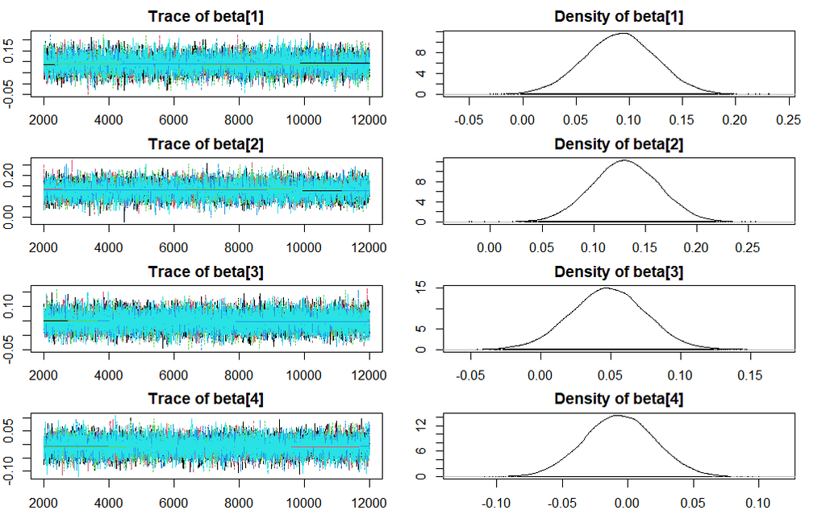

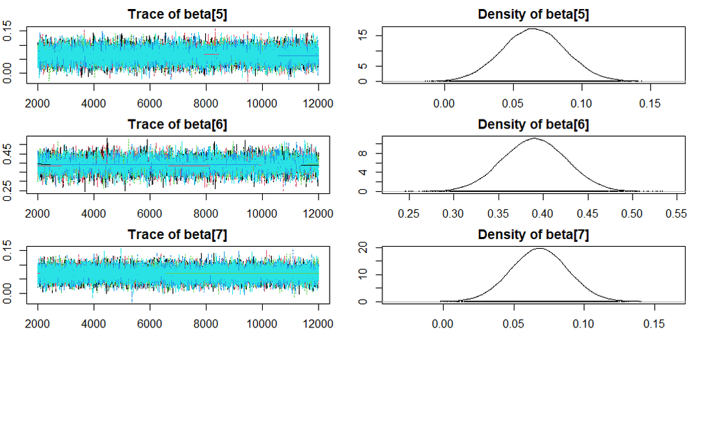

```r
par(mar=c(2,2,2,2), mfrow=c(3,2))
plot(samples_new)
```

From this plot,we can deduce that the trace plots of each variable seems covergent. However, to further confirm this, we can do convergence diagnostics.

# Convergence Diagnostics

## Geweke Diagnostics

Geweke Diagnostics reveal the convergence z-score for each chain’s parameters.

### Diagnostics

```r
for (i in 1:5){
  cat("Chain", i)
  print(geweke.diag(samples_new[[i]]))
}
```

```
Chain 1
Fraction in 1st window = 0.1
Fraction in 2nd window = 0.5

beta[1] beta[2] beta[3] beta[4] beta[5] beta[6] beta[7]
-1.1483  0.1264  0.4846  0.5508 -0.7733  0.7704  0.4375

Chain 2
Fraction in 1st window = 0.1
Fraction in 2nd window = 0.5

beta[1] beta[2] beta[3] beta[4] beta[5] beta[6] beta[7]
 0.2785  0.4010 -1.4220  3.1960 -1.6495 -1.2216  1.2791

Chain 3
Fraction in 1st window = 0.1
Fraction in 2nd window = 0.5

 beta[1]  beta[2]  beta[3]  beta[4]  beta[5]  beta[6]  beta[7]
 0.76613 -1.11185  1.40308 -0.24025 -0.90647  0.01799 -1.30070

Chain 4
Fraction in 1st window = 0.1
Fraction in 2nd window = 0.5

 beta[1]  beta[2]  beta[3]  beta[4]  beta[5]  beta[6]  beta[7]
 0.33480 -0.10108  0.18238 -0.04671 -0.24859 -0.14764 -0.52080

Chain 5
Fraction in 1st window = 0.1
Fraction in 2nd window = 0.5

 beta[1]  beta[2]  beta[3]  beta[4]  beta[5]  beta[6]  beta[7]
 0.43808 -0.03215  0.21606  0.36190  0.33482 -0.93855 -0.42128
```

### Plot

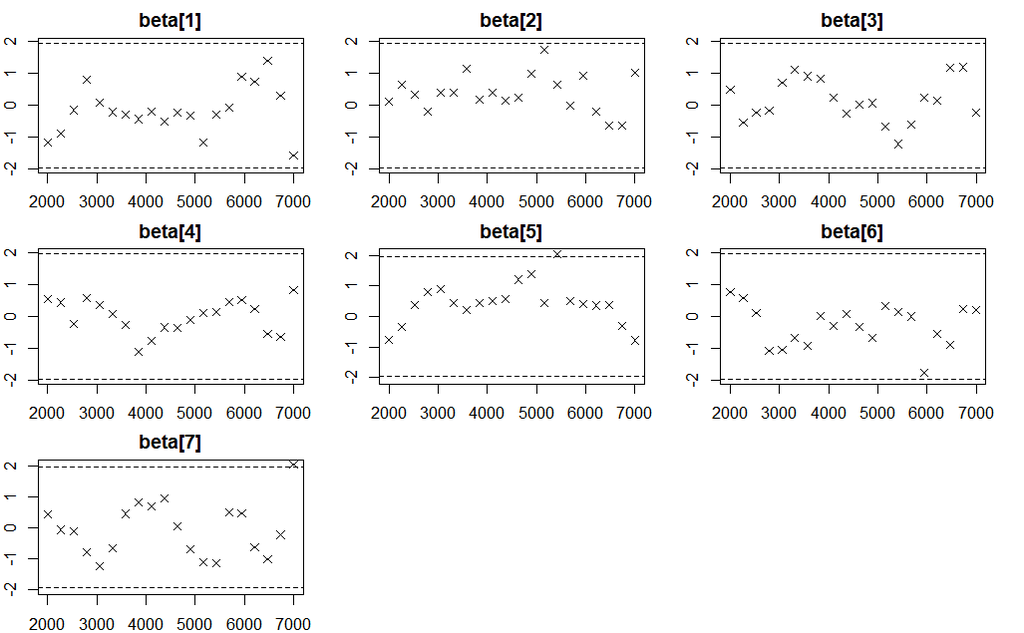

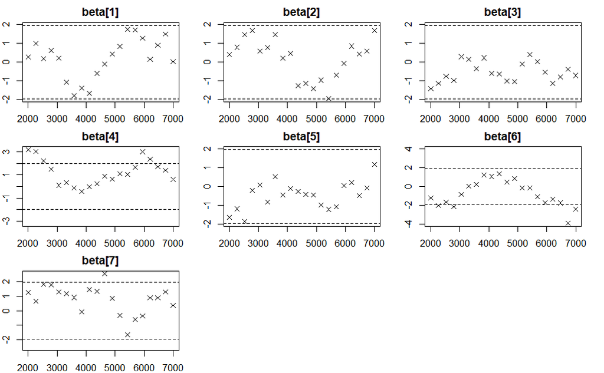

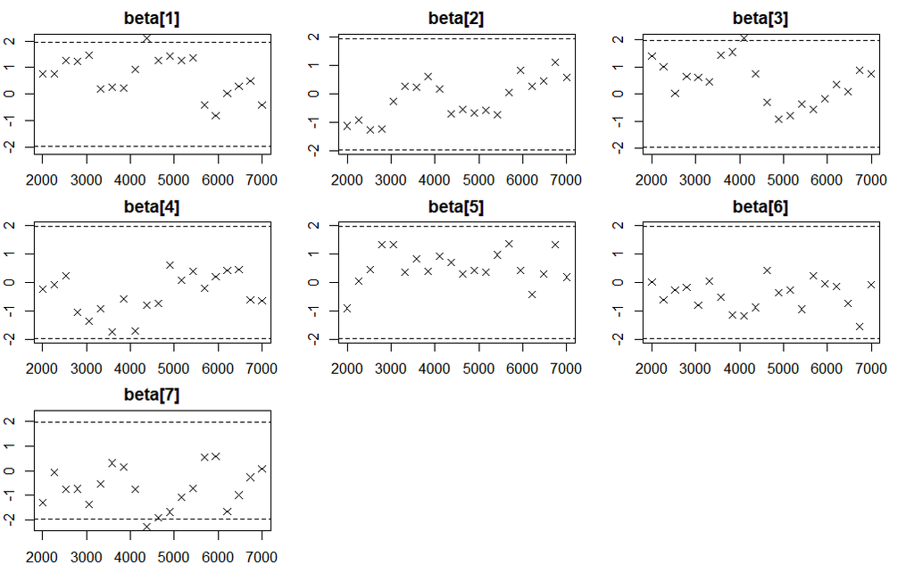

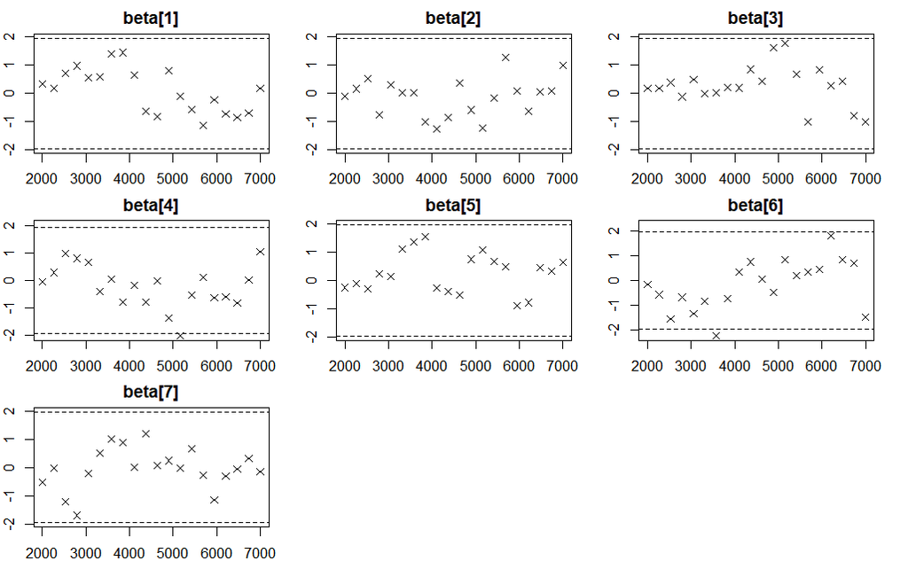

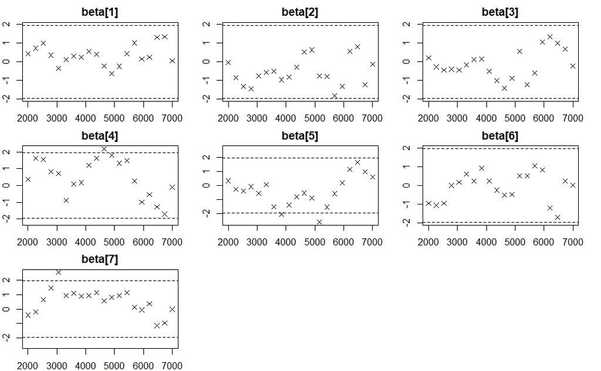

```r
par(mar=c(2,2,2,2))
for (i in 1:5){
  geweke.plot(samples_new[[i]])
}
```

## Gelman-Rubin Diagnostics

### Diagnostics

```r
gelman.diag(samples_new)
```

```
Potential scale reduction factors:

        Point est. Upper C.I.
beta[1]          1       1.01
beta[2]          1       1.01
beta[3]          1       1.00
beta[4]          1       1.00
beta[5]          1       1.00
beta[6]          1       1.00
beta[7]          1       1.00

Multivariate psrf

1
```

### Plot

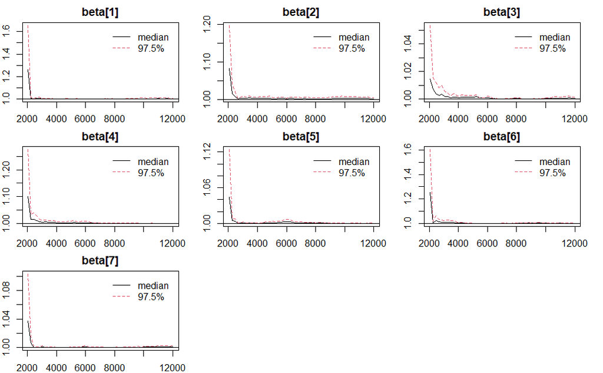

```r
par(mar=c(2,2,2,2))
gelman.plot(samples_new)
```

## Raftery-Lewis Diagnostics

```r
raftery.diag(samples_new)
```

```
[[1]]

Quantile (q) = 0.025
Accuracy (r) = +/- 0.005
Probability (s) = 0.95

         Burn-in  Total Lower bound  Dependence
         (M)      (N)   (Nmin)       factor (I)
 beta[1] 16       16556 3746         4.42
 beta[2] 12       13426 3746         3.58
 beta[3] 8        9032  3746         2.41
 beta[4] 8        9122  3746         2.44
 beta[5] 10       11582 3746         3.09
 beta[6] 14       16588 3746         4.43
 beta[7] 6        6577  3746         1.76


[[2]]

Quantile (q) = 0.025
Accuracy (r) = +/- 0.005
Probability (s) = 0.95

         Burn-in  Total Lower bound  Dependence
         (M)      (N)   (Nmin)       factor (I)
 beta[1] 12       13132 3746         3.51
 beta[2] 12       13406 3746         3.58
 beta[3] 8        8685  3746         2.32
 beta[4] 7        7967  3746         2.13
 beta[5] 7        7746  3746         2.07
 beta[6] 16       18228 3746         4.87
 beta[7] 6        6520  3746         1.74


[[3]]

Quantile (q) = 0.025
Accuracy (r) = +/- 0.005
Probability (s) = 0.95

```

[output cut: 28 more lines]

```
[[5]]

Quantile (q) = 0.025
Accuracy (r) = +/- 0.005
Probability (s) = 0.95

         Burn-in  Total Lower bound  Dependence
         (M)      (N)   (Nmin)       factor (I)
 beta[1] 16       19156 3746         5.11
 beta[2] 12       14080 3746         3.76
 beta[3] 8        9122  3746         2.44
 beta[4] 10       12266 3746         3.27
 beta[5] 10       11346 3746         3.03
 beta[6] 14       16618 3746         4.44
 beta[7] 6        6939  3746         1.85
```

```r
help(coda)
```

[output not shown]

## Effective Sample Size

```r
effectiveSize(samples_new)
```

```
  beta[1]   beta[2]   beta[3]   beta[4]   beta[5]   beta[6]   beta[7]
 5189.880  5876.794  9760.778  7934.988 13154.985  5135.275 17084.711
```

## AutoCorrelation

```r
zero_lag_max <- 0
for(i in 1:5){
  par(mar=c(2,2,2,2))
  acf_result <- acf(samples_new[[i]], plot=F)
  lags <- acf_result$lag
  acf_values <- acf_result$acf
  zero_lag_index <- which.min(abs(acf_values))
  zero_lag <- lags[zero_lag_index]
  cat("Autocorr is 0 for chain", i, "at lag", zero_lag, "\n")
  zero_lag_max = ifelse(zero_lag > zero_lag_max, zero_lag, zero_lag_max)
}
```

```
Autocorr is 0 for chain 1 at lag 17
Autocorr is 0 for chain 2 at lag -19
Autocorr is 0 for chain 3 at lag -17
Autocorr is 0 for chain 4 at lag 29
Autocorr is 0 for chain 5 at lag -27
```

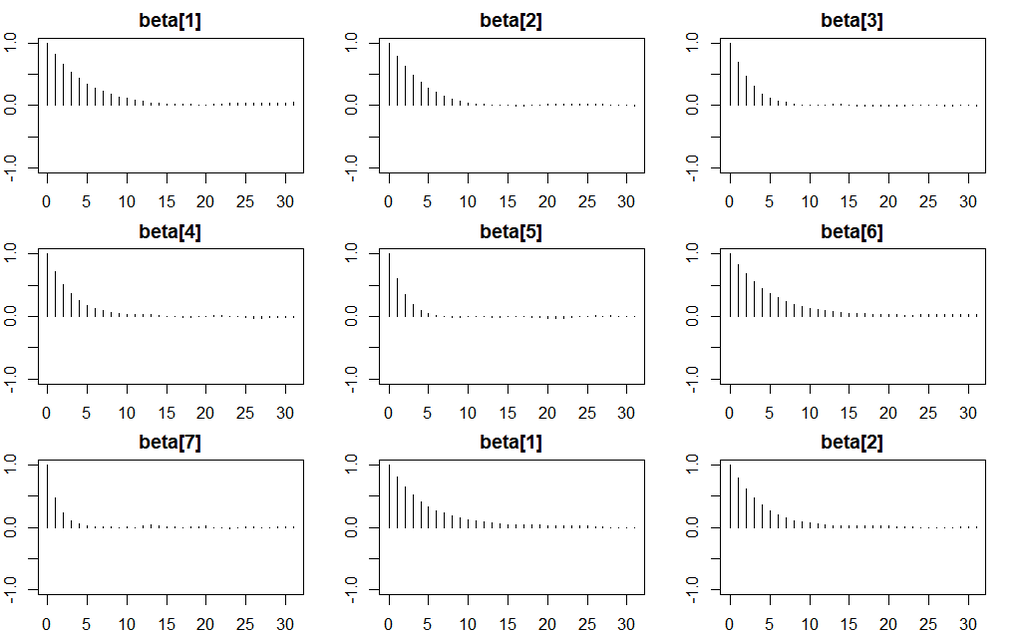

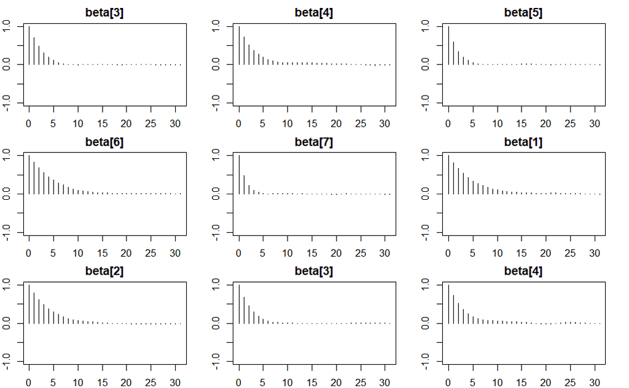

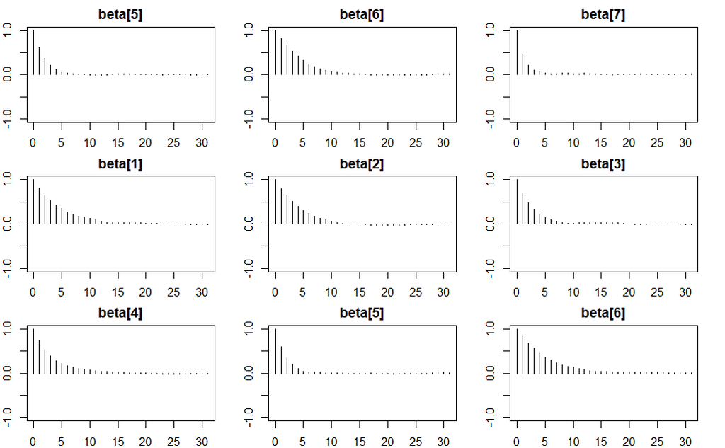

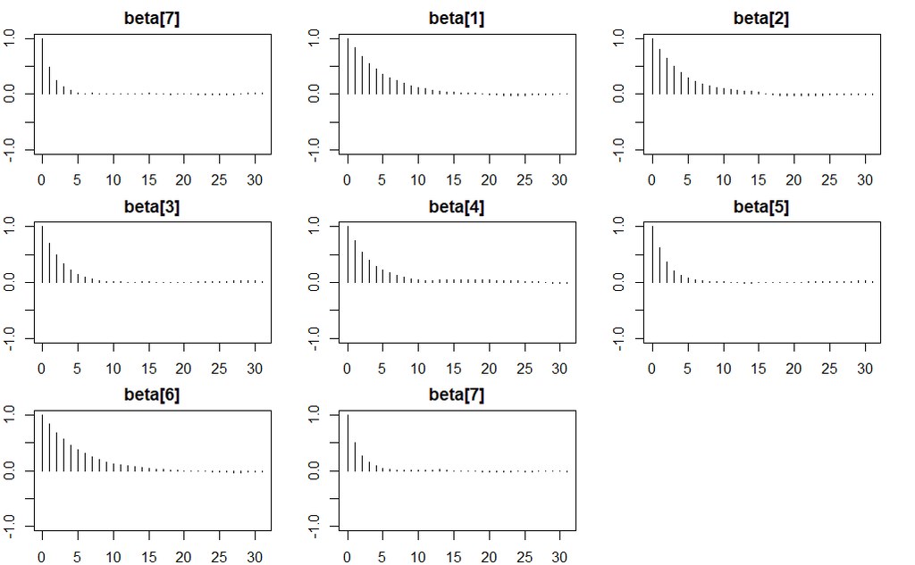

```r
par(mar=c(2,2,2,2))
autocorr.plot(samples_new)
```

# Model Comparison

```r
log_lik_matrix <- as.matrix(samples[, grep("log_lik", colnames(as.matrix(samples)))])
```

```r
lppd <- sum(log(colMeans(exp(log_lik_matrix))))  # Log pointwise predictive density
p_waic <- sum(apply(log_lik_matrix, 2, var))  # Effective number of parameters
cat("p_WAIC:", p_waic, "\n")
```

```
p_WAIC: 9.423609
```

```r
waic <- -2 * (lppd - p_waic)             # WAIC

cat("WAIC:", waic, "\n")
```

```
WAIC: -1118.644
```

```r
library(loo)
log_lik_array <- array(log_lik_matrix, dim = c(nrow(log_lik_matrix), n))

# Perform LOO-CV
loo_result <- loo(log_lik_array)

# Print the result
print(loo_result)
```

```
Computed from 50000 by 500 log-likelihood matrix.
```

|  | Estimate | SE |
| --- | --- | --- |
| elpd_loo | 708.8 | 20.9 |
| p_loo | 11.1 | 1.1 |
| looic | -1417.6 | 41.9 |

```
------
MCSE of elpd_loo is 0.0.
MCSE and ESS estimates assume independent draws (r_eff=1).

All Pareto k estimates are good (k < 0.7).
See help('pareto-k-diagnostic') for details.
```

# Predictions

```r
#Separate samples
combined_samples <- as.matrix(samples_new)

beta_0_samples <- as.matrix(samples[, "beta_0"])
beta_samples <- as.matrix(combined_samples[, grep("beta\\[", colnames(combined_samples))])
phi_samples <- as.matrix(samples[, "phi"])


n_samples <- nrow(as.matrix(samples_new))  # Number of posterior samples
n_test <- nrow(x_test)  # Number of test observations
```

```r
# Preallocate matrix for predicted mu
x_test_scaled <- as.matrix(x_test_scaled)
pred_mu <- matrix(NA, nrow = nrow(beta_samples), ncol = n_test)

# Compute predicted mu for each test observation

for (i in 1:nrow(beta_samples)) {
  pred_mu[i, ] <- plogis(beta_0_samples[i] + x_test_scaled %*% beta_samples[i, ])
}
```

```r
# Generate predictions for Y (Beta distribution)
pred_y <- matrix(NA, nrow = n_samples, ncol = n_test)
for (i in 1:n_samples) {
  for (j in 1:n_test) {
    pred_y[i, j] <- rbeta(1, phi_samples[i] * pred_mu[i, j], phi_samples[i] * (1 - pred_mu[i, j]))
  }
}
```

## Frequentist Metrics

### Model MSE (Mean Squared Error)

```r
mse <- mean((apply(pred_y, 2, mean) - y_test)^2)
print(mse)
```

```
[1] 0.003412774
```

### Baseline MSE

```r
baseline_mse <- mean((y_test - mean(y_train))^2)
baseline_mse
```

```
[1] 0.0179975
```

```r
pred_mean <- apply(pred_y, 2, mean)
pred_df <- data.frame(
  True = y_test,
  Predicted = pred_mean,
  Residual = y_test - pred_mean
)

pred_df
```

| True | Predicted | Residual |
| --- | --- | --- |
| 0.76 | 0.8001252 | -0.0401251818 |
| 0.75 | 0.7132825 | 0.0367175430 |
| 0.68 | 0.5598901 | 0.1201099082 |
| 0.84 | 0.8300175 | 0.0099824773 |
| 0.78 | 0.8432185 | -0.0632184994 |
| 0.65 | 0.6505423 | -0.0005423060 |
| 0.94 | 0.8900488 | 0.0499511522 |
| 0.97 | 0.9105084 | 0.0594916133 |
| 0.76 | 0.7675129 | -0.0075128987 |
| 0.48 | 0.5552057 | -0.0752057001 |

[output cut: 90 more lines]

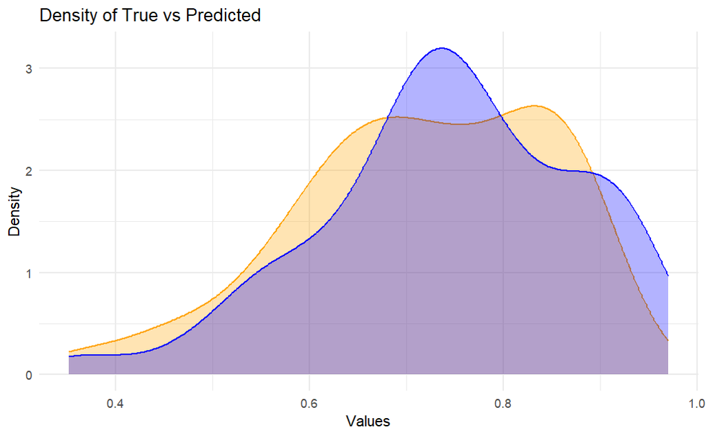

```r
ggplot() +
  geom_density(data = pred_df, aes(x = Predicted), color = "orange", fill = "orange", alpha = 0.3) +
  geom_density(data = pred_df, aes(x = True), color = "blue", fill = "blue", alpha = 0.3) +
  labs(title = "Density of True vs Predicted",
       x = "Values",
       y = "Density",
       fill = "Legend") +
  theme_minimal()
```

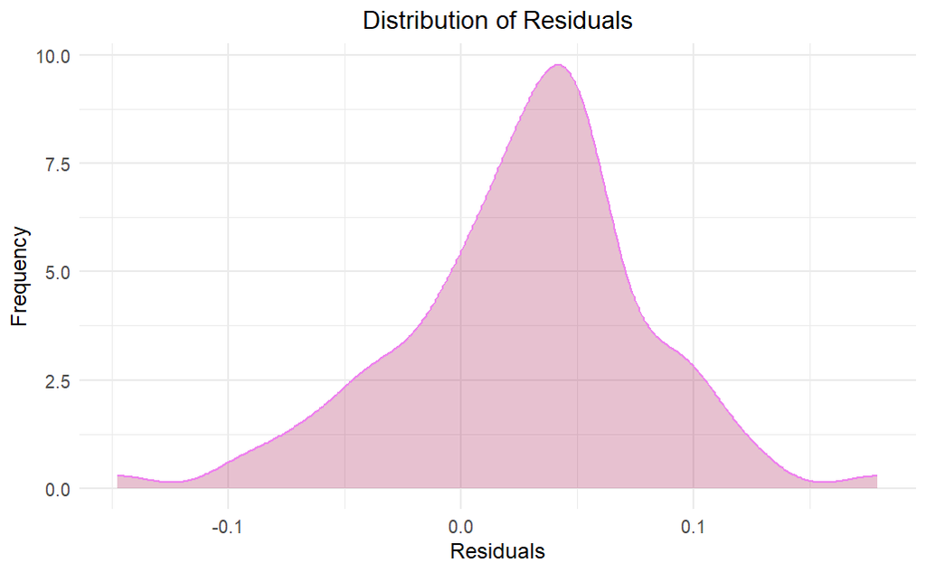

```r
#Range of Error
ggplot() +
 geom_density(data = pred_df, aes(x = Residual), color = "violet", fill = "maroon", alpha = 0.3) +
  labs(
    title = "Distribution of Residuals",
    x = "Residuals",
    y = "Frequency"
  ) +
  theme_minimal() +
  theme(
    plot.title = element_text(hjust = 0.5, size = 14),  # Centered title
    axis.title = element_text(size = 12),  # Axis labels
    axis.text = element_text(size = 10)  # Axis ticks
  )
```

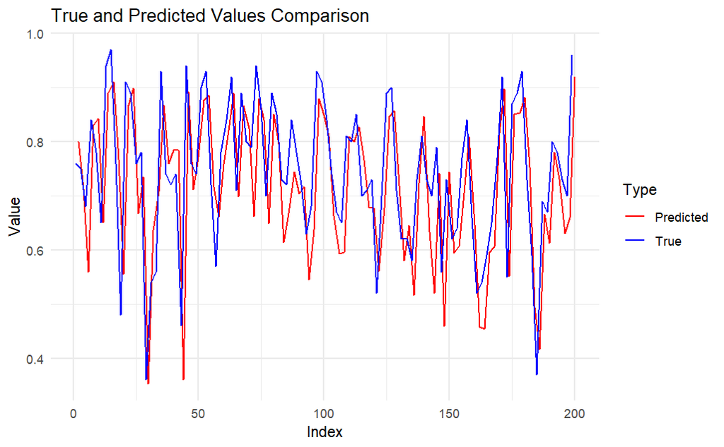

```r
library(tidyr)

pred_long <- pivot_longer(pred_df, cols = c(True, Predicted), names_to = "Type", values_to = "Value")

# Line plot for True and Predicted values
ggplot(pred_long, aes(x = seq_along(Value), y = Value, color = Type)) +
  geom_line() +
  labs(
    title = "True and Predicted Values Comparison",
    x = "Index",
    y = "Value"
  ) +
  scale_color_manual(values = c("True" = "blue", "Predicted" = "red")) +
  theme_minimal()
```

### Posterior Predicted P-Value (PPP-value)

```r
observed_mean <- mean(y_test)
predicted_mean <- apply(pred_y, 2, mean)

ppp_value <- mean(predicted_mean >= observed_mean)
print(paste("Posterior Predictive p-value:", ppp_value))
```

```
[1] "Posterior Predictive p-value: 0.46"
```